# 0a26d27e-156c-4de8-a653-c819e4ef8a53

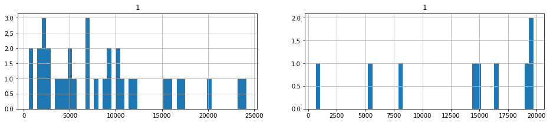

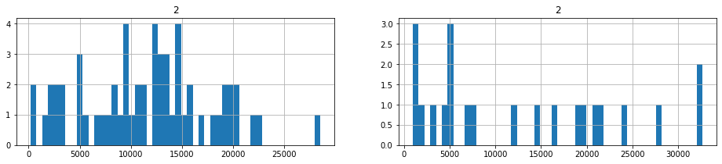

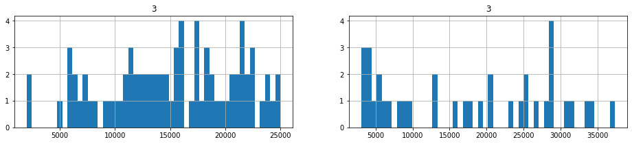

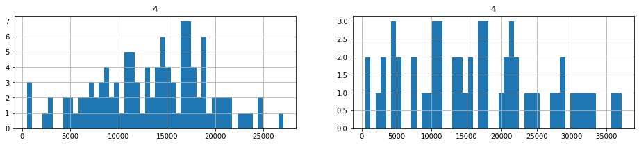

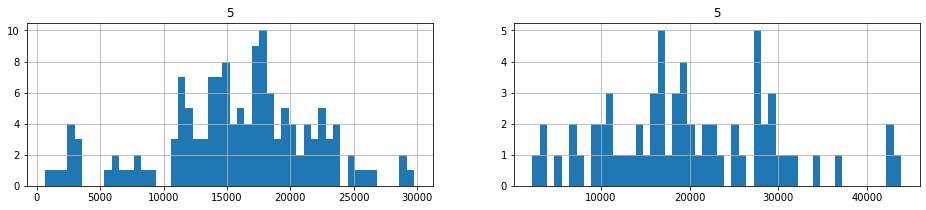

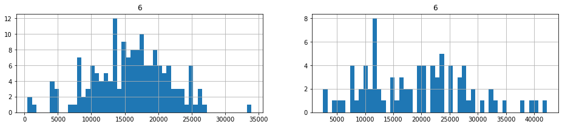

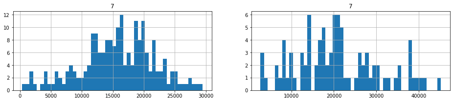

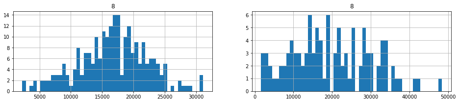

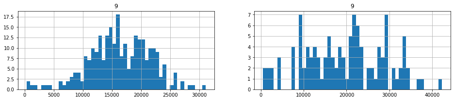

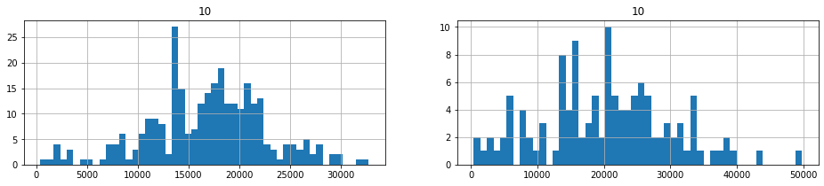

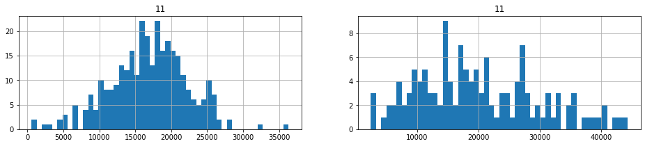

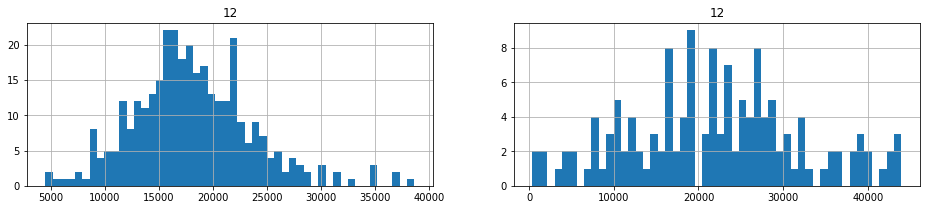

```python
for i in range(1,13):
    plt.figure(figsize=(16, 3))
    plt.subplot(1, 2, 1)
    data_internet_pivot_smart[data_internet_pivot_smart[i] != 0][i].hist(bins=50)
    plt.title(i)
    plt.subplot(1, 2, 2)
    data_internet_pivot_ultra[data_internet_pivot_ultra[i] != 0][i].hist(bins=50)
    plt.title(i)
```

## Вывод

Пользователи подключались постепенно, больше всего их к концу года, соответственно распределение показателей стремится к нормальному в конце года.

Найдём упущенную дисперсию количества минут разговора по месяцам для пользователей тарифа «Смарт», сохраним в переменную `data_calls_pivot_smart_var` и выведем на экран.

```python
data_calls_pivot_smart_var = np.var(data_calls_pivot_smart.loc[:, range(1, 13)]\
                                                        [data_calls_pivot_smart.loc[:, range(1, 13)] != 0])
data_calls_pivot_smart_var
```

```
1     22613.382920
2     35848.137931
3     36400.821049
4     33596.189433
5     34646.246366
6     29826.468742
7     32154.024504
8     34116.489809
9     32896.247671
10    34817.283719
11    31085.400454
12    39088.928536
dtype: float64
```

Аналогично для тарифа «Ультра».

```python
data_calls_pivot_ultra_var = np.var(data_calls_pivot_ultra.loc[:, range(1, 13)]\
                                                        [data_calls_pivot_ultra.loc[:, range(1, 13)] != 0])
data_calls_pivot_ultra_var
```

```
1      64855.728395
2      84034.105860
3     108645.216947
4      64836.971164
5      73984.902344
6      85092.394452
7      83376.985335
8      88620.677912
9      95944.940165
10     96432.195059
11     87876.172105
12    107315.277846
dtype: float64
```

Найдём среднее количество минут разговора по месяцам для пользователей тарифа «Смарт», сохраним в переменную `data_calls_pivot_smart_mean` и выведем на экран.

```python
data_calls_pivot_smart_mean = data_calls_pivot_smart.loc[:, range(1, 13)]\
                                                        [data_calls_pivot_smart.loc[:, range(1, 13)] != 0].mean()
data_calls_pivot_smart_mean
```

```
1     210.363636
2     299.000000
3     390.480519
4     370.810811
5     387.773050
6     398.546012
7     408.776119
8     423.743590
9     430.737452
10    428.098976
11    437.095238
12    480.494048
dtype: float64
```

Аналогично для тарифа «Ультра».

```python
data_calls_pivot_ultra_mean = data_calls_pivot_ultra.loc[:, range(1, 13)]\
                                                        [data_calls_pivot_ultra.loc[:, range(1, 13)] != 0].mean()
data_calls_pivot_ultra_mean
```

```
1     428.777778
2     310.260870
3     490.162162
4     475.830189
5     534.937500
6     497.975309
7     571.482759
8     536.441176
9     564.472727
10    582.305085
11    562.852713
12    615.544776
dtype: float64
```

Посчитаем итоговое среднее количество минут разговора для пользователей тарифа «Смарт».

```python
data_calls_pivot_smart_mean.mean()
```

```
388.8266209398186
```

Посчитаем итоговое среднее количество минут разговора для пользователей тарифа «Ультра».

```python
data_calls_pivot_ultra_mean.mean()
```

```
514.2535869361536
```

Построим график среднего количества минут разговора тарифов «Смарт» и «Ультра» по месяцам.

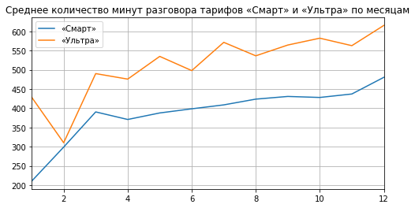

```python
plt.figure(figsize=(8, 4))
data_calls_pivot_smart_mean.plot(label='«Смарт»')
data_calls_pivot_ultra_mean.plot(label='«Ультра»')
plt.title('Cреднее количество минут разговора тарифов «Смарт» и «Ультра» по месяцам')
plt.legend()
plt.grid(True);
```

Найдём упущенную дисперсию количества сообщений по месяцам для пользователей тарифа «Смарт», сохраним в переменную `data_messages_pivot_smart_var` и выведем на экран.

```python
data_messages_pivot_smart_var = np.var(data_messages_pivot_smart.loc[:, range(1, 13)]\
                                                        [data_messages_pivot_smart.loc[:, range(1, 13)] != 0])
data_messages_pivot_smart_var
```

```
1     244.000000
2     431.656400
3     660.073514
4     512.471246
5     633.539909
6     726.483436
7     715.218259
8     763.452206
9     699.355306
10    733.603401
11    708.726694
12    829.546601
dtype: float64
```

Аналогично для тарифа «Ультра».

```python
data_messages_pivot_ultra_var = np.var(data_messages_pivot_ultra.loc[:, range(1, 13)]\
                                                        [data_messages_pivot_ultra.loc[:, range(1, 13)] != 0])
data_messages_pivot_ultra_var
```

```
1      655.959184
2      668.808594
3     1753.600000
4     1372.147272
5     1529.562130
6     1906.782357
7     2160.720961
8     1999.978177
9     1886.692078
10    2403.047224
11    2229.390555
12    2342.675141
dtype: float64
```

Найдём среднее количество сообщений по месяцам для пользователей тарифа «Смарт», сохраним в переменную `data_messages_pivot_smart_mean` и выведем на экран.

```python
data_messages_pivot_smart_mean = data_messages_pivot_smart.loc[:, range(1, 13)]\
                                                        [data_messages_pivot_smart.loc[:, range(1, 13)] != 0].mean()
data_messages_pivot_smart_mean
```

```
1     20.000000
2     27.940000
3     35.550725
4     35.864583
5     39.032787
6     38.577465
7     38.988506
8     38.750000
9     39.219731
10    39.082677
11    39.881481
12    42.264808
dtype: float64
```

Аналогично для тарифа «Ультра».

```python
data_messages_pivot_ultra_mean = data_messages_pivot_ultra.loc[:, range(1, 13)]\
                                                        [data_messages_pivot_ultra.loc[:, range(1, 13)] != 0].mean()
data_messages_pivot_ultra_mean
```

```
1     43.428571
2     32.937500
3     47.800000
4     44.512821
5     48.769231
6     52.313433
7     62.136986
8     58.897727
9     63.294737
10    69.776699
11    66.159292
12    72.008547
dtype: float64
```

Посчитаем итоговое среднее количество сообщений для пользователей тарифа «Смарт».

```python
data_messages_pivot_smart_mean.mean()
```

```
36.2627302785857
```

Посчитаем итоговое среднее количество сообщений для пользователей тарифа «Ультра».

```python
data_messages_pivot_ultra_mean.mean()
```

```
55.169628669643124
```

Построим график среднего количества сообщений тарифов «Смарт» и «Ультра» по месяцам.

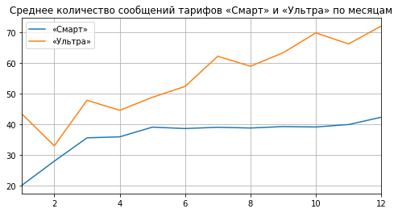

```python
plt.figure(figsize=(8, 4))
data_messages_pivot_smart_mean.plot(label='«Смарт»')
data_messages_pivot_ultra_mean.plot(label='«Ультра»')
plt.title('Cреднее количество сообщений тарифов «Смарт» и «Ультра» по месяцам')
plt.legend()
plt.grid(True);
```

Найдём упущенную дисперсию объёма интернет-трафика по месяцам для пользователей тарифа «Смарт», сохраним в переменную `data_internet_pivot_smart_var` и выведем на экран.

```python
data_internet_pivot_smart_var = np.var(data_internet_pivot_smart.loc[:, range(1, 13)]\
                                                        [data_internet_pivot_smart.loc[:, range(1, 13)] != 0])
data_internet_pivot_smart_var
```

```
1     4.040848e+07
2     3.844713e+07
3     3.361173e+07
4     3.225845e+07
5     3.557060e+07
6     3.341275e+07
7     3.468931e+07
8     3.017847e+07
9     2.696067e+07
10    3.345450e+07
11    2.849938e+07
12    3.104983e+07
dtype: float64
```

Аналогично для тарифа «Ультра».

```python
data_internet_pivot_ultra_var = np.var(data_internet_pivot_ultra.loc[:, range(1, 13)]\
                                                        [data_internet_pivot_ultra.loc[:, range(1, 13)] != 0])
data_internet_pivot_ultra_var
```

```
1     4.197903e+07
2     1.049058e+08
3     1.169232e+08
4     9.290731e+07
5     9.076461e+07
6     8.215174e+07
7     9.675161e+07
8     1.063020e+08
9     8.688305e+07
10    9.294793e+07
11    9.537295e+07
12    1.044366e+08
dtype: float64
```

Найдём среднее объёма интернет-трафика по месяцам для пользователей тарифа «Смарт», сохраним в переменную `data_internet_pivot_smart_mean` и выведем на экран.

```python
data_internet_pivot_smart_mean = data_internet_pivot_smart.loc[:, range(1, 13)]\
                                                        [data_internet_pivot_smart.loc[:, range(1, 13)] != 0].mean()
data_internet_pivot_smart_mean
```

```
1      8524.823529
2     11611.603448
3     15124.090909
4     13479.857143
5     15825.617021
6     15815.164634
7     15763.900498
8     16703.726496
9     16325.050000
10    16836.286689
11    16917.987342
12    18137.296736
dtype: float64
```

Аналогично для тарифа «Ультра».

```python
data_internet_pivot_ultra_mean = data_internet_pivot_ultra.loc[:, range(1, 13)]\
                                                        [data_internet_pivot_ultra.loc[:, range(1, 13)] != 0].mean()
data_internet_pivot_ultra_mean
```

```
1     13153.555556
2     12858.954545
3     17552.405405
4     16844.236364
5     19977.969231
6     19170.807229
7     20742.911111
8     19779.226415
9     19391.280702
10    20228.672131
11    19954.586466
12    21972.072464
dtype: float64
```

Посчитаем итоговый средний объём интернет-трафика для пользователей тарифа «Смарт».

```python
data_internet_pivot_smart_mean.mean()
```

```
15088.78370378288
```

Посчитаем итоговый средний объём интернет-трафика для пользователей тарифа «Ультра».

```python
data_internet_pivot_ultra_mean.mean()
```

```
18468.889801564805
```

Построим график среднего объёма интернет-трафика тарифов «Смарт» и «Ультра» по месяцам.

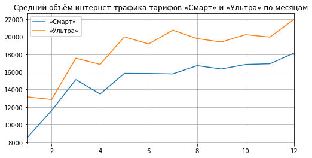

```python
plt.figure(figsize=(8, 4))
data_internet_pivot_smart_mean.plot(label='«Смарт»')
data_internet_pivot_ultra_mean.plot(label='«Ультра»')
plt.title('Cредний объём интернет-трафика тарифов «Смарт» и «Ультра» по месяцам')
plt.legend()
plt.grid(True);
```

## Вывод

Пользователи тарифа «Ультра» активнее пользуются услугами сотовой связи, чем пользователи тарифа «Смарт».

## Шаг 4. Проверьте гипотезы

Выберем пользователей тарифа «Смарт».

```python
data_users_smart.loc[:, range(1, 13)]
```

|  | 1 | 2 | 3 | 4 | 5 | 6 | 7 | 8 | 9 | 10 | 11 | 12 |
| --- | --- | --- | --- | --- | --- | --- | --- | --- | --- | --- | --- | --- |
| 1 | 0.0 | 0.0 | 0.0 | 0.0 | 0.0 | 0.0 | 0.0 | 0.0 | 0.0 | 0.0 | 1350.0 | 550.0 |
| 2 | 0.0 | 0.0 | 0.0 | 0.0 | 0.0 | 550.0 | 1150.0 | 1550.0 | 950.0 | 550.0 | 1350.0 | 1150.0 |
| 5 | 550.0 | 550.0 | 892.0 | 1186.0 | 835.0 | 886.0 | 778.0 | 952.0 | 556.0 | 1219.0 | 706.0 | 838.0 |
| 6 | 0.0 | 550.0 | 950.0 | 550.0 | 550.0 | 550.0 | 1550.0 | 1350.0 | 750.0 | 1550.0 | 550.0 | 1350.0 |
| 7 | 0.0 | 0.0 | 0.0 | 550.0 | 1150.0 | 688.0 | 984.0 | 1750.0 | 1018.0 | 550.0 | 1190.0 | 550.0 |
| ... | ... | ... | ... | ... | ... | ... | ... | ... | ... | ... | ... | ... |
| 494 | 0.0 | 0.0 | 0.0 | 0.0 | 0.0 | 0.0 | 0.0 | 550.0 | 953.0 | 1150.0 | 1150.0 | 1150.0 |
| 496 | 550.0 | 3435.0 | 2721.0 | 1819.0 | 2350.0 | 1715.0 | 2596.0 | 2431.0 | 2950.0 | 3150.0 | 3039.0 | 1807.0 |
| 497 | 0.0 | 0.0 | 0.0 | 0.0 | 0.0 | 0.0 | 0.0 | 0.0 | 0.0 | 550.0 | 550.0 | 1685.0 |
| 498 | 0.0 | 0.0 | 0.0 | 0.0 | 0.0 | 0.0 | 550.0 | 2386.0 | 1950.0 | 1750.0 | 0.0 | 0.0 |
| 499 | 0.0 | 0.0 | 0.0 | 0.0 | 0.0 | 0.0 | 0.0 | 0.0 | 550.0 | 1150.0 | 1513.0 | 598.0 |

351 rows × 12 columns

Найдём среднюю выручку пользователей тарифа «Смарт». Для этого вычислим среднее значение по строкам для всех ненулевых элементов таблицы `data_users_smart`. Сохраним результат в `list_users_smart` и выведем на экран.

```python
list_users_smart = data_users_smart.loc[:, range(1, 13)][data_users_smart.loc[:, range(1, 13)] != 0].mean(axis=1)
list_users_smart
```

```
1       950.000000
2      1035.714286
5       829.000000
6       931.818182
7       936.666667
          ...
494     990.600000
496    2380.250000
497     928.333333
498    1659.000000
499     952.750000
Length: 351, dtype: float64
```

Выберем пользователей тарифа «Ультра».

```python
data_users_ultra.loc[:, range(1, 13)]
```

|  | 1 | 2 | 3 | 4 | 5 | 6 | 7 | 8 | 9 | 10 | 11 | 12 |
| --- | --- | --- | --- | --- | --- | --- | --- | --- | --- | --- | --- | --- |
| 0 | 0.0 | 0.0 | 0.0 | 0.0 | 1950.0 | 1950.0 | 1950.0 | 1950.0 | 1950.0 | 1950.0 | 1950.0 | 1950.0 |
| 3 | 0.0 | 0.0 | 0.0 | 0.0 | 0.0 | 0.0 | 0.0 | 1950.0 | 1950.0 | 1950.0 | 1950.0 | 1950.0 |
| 4 | 0.0 | 0.0 | 0.0 | 0.0 | 1950.0 | 1950.0 | 1950.0 | 1950.0 | 1950.0 | 1950.0 | 1950.0 | 1950.0 |
| 13 | 0.0 | 0.0 | 0.0 | 0.0 | 0.0 | 0.0 | 0.0 | 0.0 | 0.0 | 0.0 | 1950.0 | 1950.0 |
| 16 | 0.0 | 0.0 | 0.0 | 0.0 | 0.0 | 0.0 | 0.0 | 0.0 | 0.0 | 0.0 | 1950.0 | 1950.0 |
| ... | ... | ... | ... | ... | ... | ... | ... | ... | ... | ... | ... | ... |
| 476 | 0.0 | 0.0 | 0.0 | 1950.0 | 1950.0 | 1950.0 | 1950.0 | 1950.0 | 1950.0 | 1950.0 | 1950.0 | 1950.0 |
| 485 | 0.0 | 0.0 | 0.0 | 0.0 | 0.0 | 0.0 | 0.0 | 0.0 | 0.0 | 0.0 | 0.0 | 1950.0 |
| 491 | 0.0 | 0.0 | 0.0 | 1950.0 | 1950.0 | 1950.0 | 1950.0 | 1950.0 | 1950.0 | 1950.0 | 1950.0 | 1950.0 |
| 493 | 0.0 | 0.0 | 0.0 | 0.0 | 0.0 | 0.0 | 0.0 | 0.0 | 0.0 | 0.0 | 1950.0 | 3750.0 |
| 495 | 0.0 | 0.0 | 0.0 | 0.0 | 0.0 | 0.0 | 0.0 | 1950.0 | 2400.0 | 1950.0 | 3300.0 | 1950.0 |

149 rows × 12 columns

Найдём среднюю выручку пользователей тарифа «Ультра». Для этого вычислим среднее значение по строкам для всех ненулевых элементов таблицы `data_users_ultra`. Сохраним результат в `list_users_ultra` и выведем на экран.

```python
list_users_ultra = data_users_ultra.loc[:, range(1, 13)][data_users_ultra.loc[:, range(1, 13)] != 0].mean(axis=1)
list_users_ultra
```

```
0      1950.0
3      1950.0
4      1950.0
13     1950.0
16     1950.0
        ...
476    1950.0
485    1950.0
491    1950.0
493    2850.0
495    2310.0
Length: 149, dtype: float64
```

Сравним среднюю выручку пользователей тарифов «Смарт» и «Ультра». Для этого проверим гипотезу о равенстве среднего двух генеральных совокупностей методом `scipy.stats.ttest_ind()`.

```python
alpha = 0.05 # пороговое значение

results = st.ttest_ind(
    list_users_smart,
    list_users_ultra,
    equal_var = False
)

print('p-значение:', results.pvalue)

if (results.pvalue < alpha):
    print("Отвергаем нулевую гипотезу")
else:
    print("Не получилось отвергнуть нулевую гипотезу")
```

```
p-значение: 7.689671550143974e-59
Отвергаем нулевую гипотезу
```

Cредняя выручка пользователей тарифов «Ультра» и «Смарт» различается.

```python
np.var(list_users_smart)
```

```
368543.8372584689
```

```python
np.var(list_users_ultra)
```

```
89420.18554420327
```

Выберем пользователей тарифа «Смарт», проживающих в Москве, сохраним их в `data_users_smart_moscow` и выведем на экран.

```python
data_users_smart_moscow = data_users_smart.query('city == "Москва"').loc[:, range(1, 13)]
data_users_smart_moscow
```

|  | 1 | 2 | 3 | 4 | 5 | 6 | 7 | 8 | 9 | 10 | 11 | 12 |
| --- | --- | --- | --- | --- | --- | --- | --- | --- | --- | --- | --- | --- |
| 1 | 0.0 | 0.0 | 0.0 | 0.0 | 0.0 | 0.0 | 0.0 | 0.0 | 0.0 | 0.0 | 1350.0 | 550.0 |
| 7 | 0.0 | 0.0 | 0.0 | 550.0 | 1150.0 | 688.0 | 984.0 | 1750.0 | 1018.0 | 550.0 | 1190.0 | 550.0 |
| 31 | 0.0 | 0.0 | 0.0 | 0.0 | 0.0 | 0.0 | 0.0 | 0.0 | 0.0 | 0.0 | 1048.0 | 736.0 |
| 33 | 0.0 | 0.0 | 0.0 | 0.0 | 0.0 | 0.0 | 550.0 | 2031.0 | 2831.0 | 1640.0 | 2616.0 | 1816.0 |
| 38 | 0.0 | 0.0 | 0.0 | 0.0 | 0.0 | 0.0 | 0.0 | 0.0 | 0.0 | 950.0 | 550.0 | 950.0 |
| ... | ... | ... | ... | ... | ... | ... | ... | ... | ... | ... | ... | ... |
| 447 | 0.0 | 0.0 | 0.0 | 0.0 | 0.0 | 0.0 | 0.0 | 0.0 | 550.0 | 1806.0 | 1827.0 | 3148.0 |
| 449 | 0.0 | 0.0 | 0.0 | 0.0 | 0.0 | 0.0 | 550.0 | 1023.0 | 1192.0 | 1005.0 | 1926.0 | 931.0 |
| 450 | 0.0 | 0.0 | 0.0 | 0.0 | 0.0 | 0.0 | 0.0 | 0.0 | 0.0 | 550.0 | 1634.0 | 891.0 |
| 481 | 0.0 | 550.0 | 1150.0 | 1550.0 | 1150.0 | 550.0 | 1350.0 | 1750.0 | 950.0 | 1150.0 | 1550.0 | 950.0 |
| 490 | 0.0 | 0.0 | 0.0 | 550.0 | 1750.0 | 1550.0 | 586.0 | 950.0 | 550.0 | 1750.0 | 1350.0 | 750.0 |

67 rows × 12 columns

Выберем пользователей тарифа «Смарт», проживающих в других регионах, сохраним их в `data_users_smart_not_moscow`, и выведем на экран.

```python
data_users_smart_not_moscow = data_users_smart.query('city != "Москва"').loc[:, range(1, 13)]
data_users_smart_not_moscow
```

|  | 1 | 2 | 3 | 4 | 5 | 6 | 7 | 8 | 9 | 10 | 11 | 12 |
| --- | --- | --- | --- | --- | --- | --- | --- | --- | --- | --- | --- | --- |
| 2 | 0.0 | 0.0 | 0.0 | 0.0 | 0.0 | 550.0 | 1150.0 | 1550.0 | 950.0 | 550.0 | 1350.0 | 1150.0 |
| 5 | 550.0 | 550.0 | 892.0 | 1186.0 | 835.0 | 886.0 | 778.0 | 952.0 | 556.0 | 1219.0 | 706.0 | 838.0 |
| 6 | 0.0 | 550.0 | 950.0 | 550.0 | 550.0 | 550.0 | 1550.0 | 1350.0 | 750.0 | 1550.0 | 550.0 | 1350.0 |
| 8 | 0.0 | 0.0 | 0.0 | 0.0 | 0.0 | 0.0 | 0.0 | 0.0 | 0.0 | 0.0 | 0.0 | 568.0 |
| 9 | 0.0 | 0.0 | 550.0 | 550.0 | 550.0 | 750.0 | 2550.0 | 2350.0 | 1950.0 | 1550.0 | 950.0 | 1350.0 |
| ... | ... | ... | ... | ... | ... | ... | ... | ... | ... | ... | ... | ... |
| 494 | 0.0 | 0.0 | 0.0 | 0.0 | 0.0 | 0.0 | 0.0 | 550.0 | 953.0 | 1150.0 | 1150.0 | 1150.0 |
| 496 | 550.0 | 3435.0 | 2721.0 | 1819.0 | 2350.0 | 1715.0 | 2596.0 | 2431.0 | 2950.0 | 3150.0 | 3039.0 | 1807.0 |
| 497 | 0.0 | 0.0 | 0.0 | 0.0 | 0.0 | 0.0 | 0.0 | 0.0 | 0.0 | 550.0 | 550.0 | 1685.0 |
| 498 | 0.0 | 0.0 | 0.0 | 0.0 | 0.0 | 0.0 | 550.0 | 2386.0 | 1950.0 | 1750.0 | 0.0 | 0.0 |
| 499 | 0.0 | 0.0 | 0.0 | 0.0 | 0.0 | 0.0 | 0.0 | 0.0 | 550.0 | 1150.0 | 1513.0 | 598.0 |

284 rows × 12 columns

Найдём среднюю выручку пользователей тарифа «Смарт», проживающих в Москве. Для этого вычислим среднее значение по строкам для всех ненулевых элементов таблицы `data_users_smart_moscow`. Сохраним результат в `list_users_smart_moscow` и выведем на экран.

```python
list_users_smart_moscow = data_users_smart_moscow[data_users_smart_moscow != 0].mean(axis=1)
list_users_smart_moscow
```

```
1       950.000000
7       936.666667
31      892.000000
33     1914.000000
38      816.666667
          ...
447    1832.750000
449    1104.500000
450    1025.000000
481    1150.000000
490    1087.333333
Length: 67, dtype: float64
```

Найдём среднюю выручку пользователей тарифа «Смарт», проживающих в в других регионах. Для этого вычислим среднее значение по строкам для всех ненулевых элементов таблицы `data_users_smart_not_moscow`. Сохраним результат в `list_users_smart_not_moscow` и выведем на экран.

```python
list_users_smart_not_moscow = data_users_smart_not_moscow[data_users_smart_not_moscow != 0].mean(axis=1)
list_users_smart_not_moscow
```

```
2      1035.714286
5       829.000000
6       931.818182
8       568.000000
9      1310.000000
          ...
494     990.600000
496    2380.250000
497     928.333333
498    1659.000000
499     952.750000
Length: 284, dtype: float64
```

Сравним среднюю выручку пользователей тарифа «Смарт» из Москвы и выручку пользователей из других регионов. Для этого проверим гипотезу о равенстве среднего двух генеральных совокупностей методом `scipy.stats.ttest_ind()`.

```python
results = st.ttest_ind(
    list_users_smart_moscow,
    list_users_smart_not_moscow,
    equal_var = False
)

print('p-значение:', results.pvalue)

if (results.pvalue < alpha):
    print("Отвергаем нулевую гипотезу")
else:
    print("Не получилось отвергнуть нулевую гипотезу")
```

```
p-значение: 0.14993780434254916
Не получилось отвергнуть нулевую гипотезу
```

```python
np.var(list_users_smart_moscow)
```

```
296078.1366961734
```

```python
np.var(list_users_smart_not_moscow)
```

```
383295.9219288168
```

Cредняя выручка пользователей тарифа «Смарт» из Москвы не отличается от выручки пользователей тарифа «Смарт» из других регионов.

Выберем пользователей тарифа «Ультра», проживающих в Москве, сохраним их в `data_users_ultra_moscow` и выведем на экран.

```python
data_users_ultra_moscow = data_users_ultra.query('city == "Москва"').loc[:, range(1, 13)]
data_users_ultra_moscow.head()
```

|  | 1 | 2 | 3 | 4 | 5 | 6 | 7 | 8 | 9 | 10 | 11 | 12 |
| --- | --- | --- | --- | --- | --- | --- | --- | --- | --- | --- | --- | --- |
| 3 | 0.0 | 0.0 | 0.0 | 0.0 | 0.0 | 0.0 | 0.0 | 1950.0 | 1950.0 | 1950.0 | 1950.0 | 1950.0 |
| 49 | 0.0 | 0.0 | 1950.0 | 1950.0 | 1950.0 | 1950.0 | 1950.0 | 1950.0 | 1950.0 | 1950.0 | 1950.0 | 1950.0 |
| 57 | 0.0 | 0.0 | 1950.0 | 1950.0 | 1950.0 | 1950.0 | 1950.0 | 1950.0 | 1950.0 | 1950.0 | 1950.0 | 1950.0 |
| 80 | 0.0 | 0.0 | 0.0 | 0.0 | 0.0 | 0.0 | 0.0 | 1950.0 | 1950.0 | 1950.0 | 1950.0 | 1950.0 |
| 81 | 0.0 | 0.0 | 1950.0 | 1950.0 | 1950.0 | 1950.0 | 1950.0 | 1950.0 | 1950.0 | 1950.0 | 1950.0 | 1950.0 |

Выберем пользователей тарифа «Ультра», проживающих в других регионах, сохраним их в `data_users_ultra_not_moscow`, и выведем на экран.

```python
data_users_ultra_not_moscow = data_users_ultra.query('city != "Москва"').loc[:, range(1, 13)]
data_users_ultra_not_moscow
```

|  | 1 | 2 | 3 | 4 | 5 | 6 | 7 | 8 | 9 | 10 | 11 | 12 |
| --- | --- | --- | --- | --- | --- | --- | --- | --- | --- | --- | --- | --- |
| 0 | 0.0 | 0.0 | 0.0 | 0.0 | 1950.0 | 1950.0 | 1950.0 | 1950.0 | 1950.0 | 1950.0 | 1950.0 | 1950.0 |
| 4 | 0.0 | 0.0 | 0.0 | 0.0 | 1950.0 | 1950.0 | 1950.0 | 1950.0 | 1950.0 | 1950.0 | 1950.0 | 1950.0 |
| 13 | 0.0 | 0.0 | 0.0 | 0.0 | 0.0 | 0.0 | 0.0 | 0.0 | 0.0 | 0.0 | 1950.0 | 1950.0 |
| 16 | 0.0 | 0.0 | 0.0 | 0.0 | 0.0 | 0.0 | 0.0 | 0.0 | 0.0 | 0.0 | 1950.0 | 1950.0 |
| 18 | 0.0 | 0.0 | 0.0 | 1950.0 | 1950.0 | 1950.0 | 1950.0 | 1950.0 | 1950.0 | 1950.0 | 1950.0 | 1950.0 |
| ... | ... | ... | ... | ... | ... | ... | ... | ... | ... | ... | ... | ... |
| 474 | 0.0 | 0.0 | 0.0 | 0.0 | 0.0 | 0.0 | 0.0 | 0.0 | 0.0 | 0.0 | 1950.0 | 3750.0 |
| 485 | 0.0 | 0.0 | 0.0 | 0.0 | 0.0 | 0.0 | 0.0 | 0.0 | 0.0 | 0.0 | 0.0 | 1950.0 |
| 491 | 0.0 | 0.0 | 0.0 | 1950.0 | 1950.0 | 1950.0 | 1950.0 | 1950.0 | 1950.0 | 1950.0 | 1950.0 | 1950.0 |
| 493 | 0.0 | 0.0 | 0.0 | 0.0 | 0.0 | 0.0 | 0.0 | 0.0 | 0.0 | 0.0 | 1950.0 | 3750.0 |
| 495 | 0.0 | 0.0 | 0.0 | 0.0 | 0.0 | 0.0 | 0.0 | 1950.0 | 2400.0 | 1950.0 | 3300.0 | 1950.0 |

117 rows × 12 columns

Найдём среднюю выручку пользователей тарифа «Ультра», проживающих в Москве. Для этого вычислим среднее значение по строкам для всех ненулевых элементов таблицы `data_users_ultra_moscow`. Сохраним результат в `list_users_ultra_moscow` и выведем на экран.

```python
list_users_ultra_moscow = data_users_ultra_moscow[data_users_ultra_moscow != 0].mean(axis=1)
list_users_ultra_moscow.head()
```

```
3     1950.0
49    1950.0
57    1950.0
80    1950.0
81    1950.0
dtype: float64
```

Найдём среднюю выручку пользователей тарифа «Ультра», проживающих в в других регионах. Для этого вычислим среднее значение по строкам для всех ненулевых элементов таблицы `data_users_ultra_not_moscow`. Сохраним результат в `list_users_ultra_not_moscow` и выведем на экран.

```python
list_users_ultra_not_moscow = data_users_ultra_not_moscow[data_users_ultra_not_moscow != 0].mean(axis=1)
list_users_ultra_not_moscow
```

```
0      1950.0
4      1950.0
13     1950.0
16     1950.0
18     1950.0
        ...
474    2850.0
485    1950.0
491    1950.0
493    2850.0
495    2310.0
Length: 117, dtype: float64
```

Сравним среднюю выручку пользователей тарифа «Ультра» из Москвы и выручку пользователей из других регионов. Для этого проверим гипотезу о равенстве среднего двух генеральных совокупностей методом `scipy.stats.ttest_ind()`.

```python
results = st.ttest_ind(
    list_users_ultra_moscow,
    list_users_ultra_not_moscow,
    equal_var = False
)

print('p-значение:', results.pvalue)

if (results.pvalue < alpha):
    print("Отвергаем нулевую гипотезу")
else:
    print("Не получилось отвергнуть нулевую гипотезу")
```

```
p-значение: 0.48164162894509566
Не получилось отвергнуть нулевую гипотезу
```

```python
np.var(list_users_ultra_moscow)
```

```
40193.89686492251
```

```python
np.var(list_users_ultra_not_moscow)
```

```
102649.57007101324
```

Cредняя выручка пользователей тарифа «Ультра» из Москвы не отличается от выручки пользователей тарифа «Ультра» из других регионов.

## Вывод

Cредняя выручка пользователей тарифов «Ультра» и «Смарт» различается.

Cредняя выручка пользователей из Москвы не отличается от выручки пользователей из других регионов.

## Шаг 5. Напишите общий вывод

Аномалий и ошибок в данных я не обнаружил. Нулевые значения длительности звонков и потраченного интернет-трафика не влияют на выручку, поэтому оставлены без изменений.

Некоторые пользователи не совершают звонки, другие не отправляют сообщения, третьи не пользуются интернетом.

Абонентская плата тарифа «Ультра», как правило, покрывает потребности пользователей, а пользователи тарифа «Смарт» часто выходят за пределы тарифного пакета.

Пользователи подключались постепенно, больше всего их к концу года, соответственно распределение показателей стремится к нормальному в конце года.

Пользователи тарифа «Ультра» активнее пользуются услугами сотовой связи, чем пользователи тарифа «Смарт».

Cредняя выручка пользователей тарифов «Ультра» и «Смарт» различается.

Cредняя выручка пользователей из Москвы не отличается от выручки пользователей из других регионов.

```python
list_users_smart.describe()
```

```
count     351.000000
mean     1328.525755
std       607.944750
min       550.000000
25%       875.250000
50%      1177.600000
75%      1682.722222
max      4334.333333
dtype: float64
```

```python
list_users_ultra.describe()
```

```
count     149.000000
mean     2086.495177
std       300.040624
min      1950.000000
25%      1950.000000
50%      1950.000000
75%      1987.500000
max      3262.500000
dtype: float64
```

Сравним суммарную выручку пользователей тарифов «Смарт» и «Ультра».

```python
list_users_smart.sum()
```

```
466312.5398629148
```

```python
list_users_ultra.sum()
```

```
310887.78138528136
```

Несмотря на то, что у пользователей «Ультра» выше средние и медианные суммы, у пользователей «Смарт» выше суммарная выручка и разброс сумм. Расходы пользователей «Ультра» редко превышают двух тысяч. Расходы пользователей «Смарт» ниже, но максимальные суммы выше, поэтому есть потенциал роста. (В тренажёре Тема 2. Описательная статистика, Урок. Скошенность наборов данных есть похожий пример.)

## Вывод

У тарифа «Смарт» выше суммарная выручка и потенциал для её увеличения.